# Lecture

## Example 4: spectrum of AR(2)

Consider $X_t = \alpha_1 X_{t-1} + \alpha_2 X_{t-2} + Z_t$.

Without derivation, $$ f(\omega) = \frac{\sigma^2_Z}{\pi \left( 1 + \alpha_1^2 + \alpha_2^2 - 2 \alpha_1 (1 - \alpha_2) \cos{\omega} - 2 \alpha_2 \cos{2\omega} \right)} $$

```python
def ar_2_f(w, sigma_z, alpha_1, alpha_2):
    return sigma_z ** 2 / (np.pi * (1 + alpha_1 ** 2 + alpha_2 ** 2 - 2 * alpha_1 * (1 - alpha_2) * np.cos(w) - 2 * alpha_2 * np.cos(2 * w)))
```

```python
w = np.linspace(0, np.pi, 100)
sigma_z = 1
f_left = ar_2_f(w, sigma_z, 0.5, 0.1)
f_mid = ar_2_f(w, sigma_z, 0.5, -0.5)
f_right = ar_2_f(w, sigma_z, -0.5, 0.1)
f_mid_low = ar_2_f(w, sigma_z, 0.1, 0.5)
```

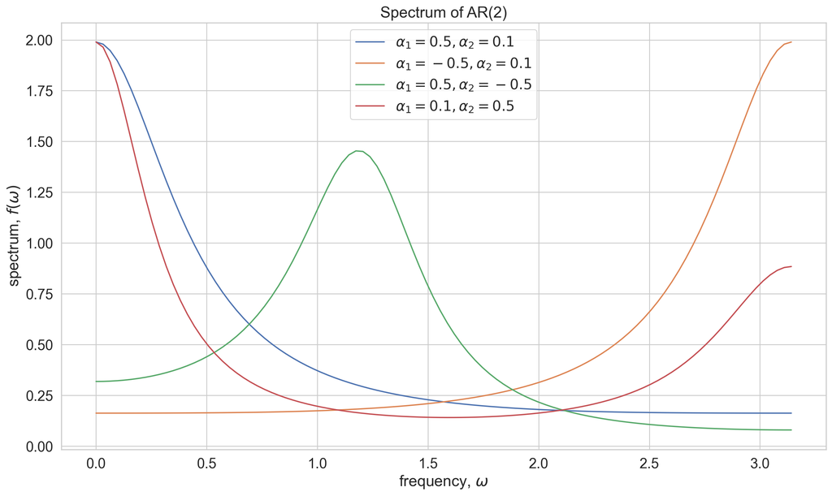

```python
fig, ax = plt.subplots(figsize=(16,9))
ax.plot(w, f_left, label="$\\alpha_1 = 0.5, \\alpha_2 = 0.1$")
ax.plot(w, f_right, label="$\\alpha_1 = -0.5, \\alpha_2 = 0.1$")
ax.plot(w, f_mid, label="$\\alpha_1 = 0.5, \\alpha_2 = -0.5$")
ax.plot(w, f_mid_low, label="$\\alpha_1 = 0.1, \\alpha_2 = 0.5$")
ax.set_xlabel("frequency, $\\omega$")
ax.set_ylabel("spectrum, $f(\\omega)$")
ax.set_title("Spectrum of AR(2)")
ax.legend();
```

## Example 5: spectrum of deterministic process

Consider $X_t = \cos (\omega_0 t + \phi)$, where $\phi \sim U[0, 2\pi]$. As discussed previously, $$ \gamma(k) = \frac12 \cos \omega_0 k $$ $$ F(\omega) = \begin{cases} 0, \; \omega < \omega_0, \\ \frac12, \; \omega \geqslant \omega_0 \end{cases} $$ $$ f(\omega) = 0, \; \forall \omega \neq \omega_0 $$

## Spectral analysis

Spectral analysis is the name given to methods of estimating the spectral density function, or spectrum, of a given time series. Traditional spectral analysis is essentially a modification of Fourier analysis so as to make it suitable for stochastic rather than deterministic functions of time. The Fourier series representation has $N$ parameters to describe $N$ observations and so can be made to fit the data exactly. The overall effect of the Fourier analysis of the data is to partition the variability of the series into components at the specified $N$ frequencies called harmonics.

## Discrete Fourier Transform

Given time series $X_t$, DFT transforms it into the same number of frequency components $\omega_k$: $$ \omega_k = \sum_{t=0}^{T-1} X_t e^{- 2 \pi i k t / T} $$

## Parseval's theorem

The Fourier transform is **unitary**. Loosely, that the sum of the square of a function is equal to the sum of the square of its transform: $$ \sum_{t=0}^{T-1} |X_t|^2 = \frac1T \sum_{k=0}^{T-1} |\omega_k|^2 = \sum_{k=0}^{T-1} \frac1T |\omega_k|^2 = \sum_{k=0}^{T-1} I(\omega_k) $$

## Periodogram

$$ I(\omega) = \frac1T |\omega|^2 $$

Plot $I(\omega)$ vs $\omega$ is called periodogram.

## Properties of periodogram

1. Periodogram is the DFT of ACVF: $$ I(\omega_p) = \frac1\pi \left( c_0 + 2 \sum_{k=1}^{T-1} c_k \cos{\omega_p k} \right) $$
2. Asymptotically unbiased estimate of the power spectrum
3. Not consistent estimate!

## Better estimates

$$ \hat{f}(\omega) = \frac1\pi \left( \lambda_0 c_0 + 2 \sum_{k=0}^M \lambda_k c_k \cos{\omega k} \right) $$

1. Tukey window $$ \lambda_k = \frac12 \left( 1 + \cos{\frac{\pi k}{M}} \right) $$

## Example

# Webinar

```python
import numpy as np
import pandas as pd

import IPython.display as dp
import matplotlib.pyplot as plt
import seaborn as sns

dp.set_matplotlib_formats("retina")
sns.set(style="whitegrid", font_scale=1.5)
sns.despine()

%matplotlib inline
```

```python
from darts import TimeSeries
import darts.datasets as ds
import scipy.stats as sts
import statsmodels.api as sm
import statsmodels.tsa.api as tsa
from darts.utils.statistics import plot_acf
```

```python
from scipy.signal import periodogram
```

```python
from scipy.signal import find_peaks
```

```python
from astsadata import speech, cmort
```

[output not shown]

[output cut: 19 more lines]

```python
cmort_ts = TimeSeries.from_series(cmort.set_index(
    pd.date_range(
        cmort.index[0].start_time.date(),
        periods=508,
        freq="W-MON",
        inclusive="both"
    )
))
```

[figure not shown]

```python
fig, ax = plt.subplots(figsize=(16,9))
cmort_ts.plot(ax=axs)
```

```python
freq, psd = periodogram(cmort_ts.values().flatten(), fs=52.18)
```

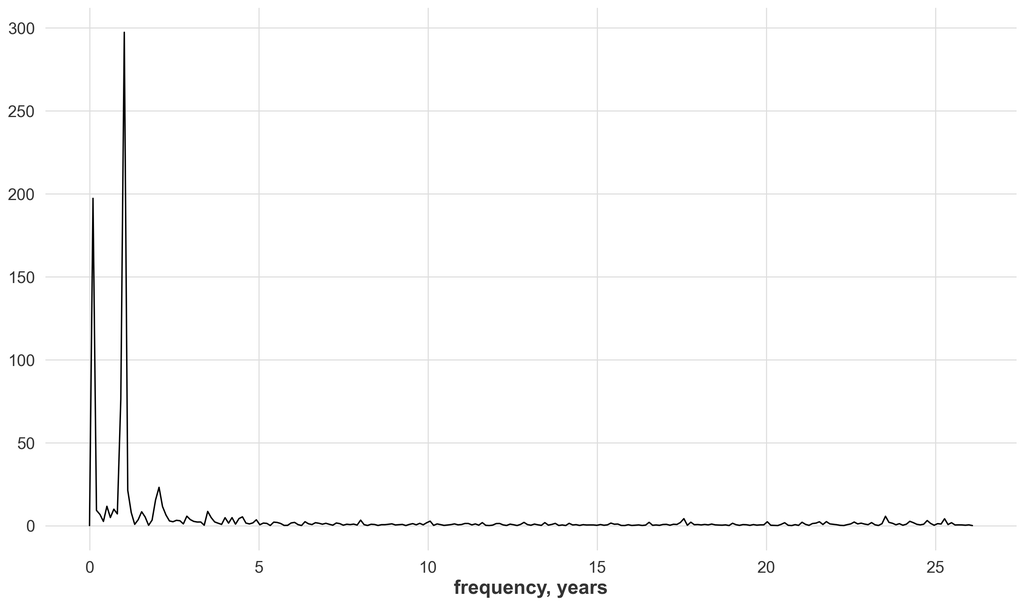

```python
fig, ax = plt.subplots(figsize=(16,9))
ax.plot(freq, psd)
ax.set_xlabel("frequency, years")
```

```python
freq[find_peaks(psd, threshold=50)[0]]
```

```
array([0.10271654, 1.02716535])
```

```python
from darts.utils.statistics import plot_acf
```

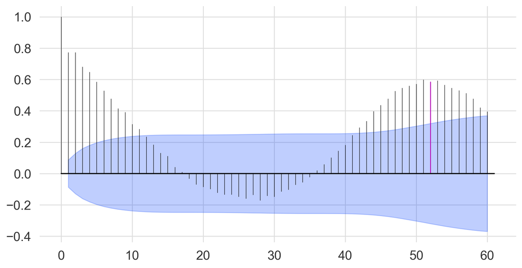

```python
plot_acf(cmort_ts, max_lag=60, m=52)
```

```python
cmort_sdiff_ts = cmort_ts.diff(52)
```

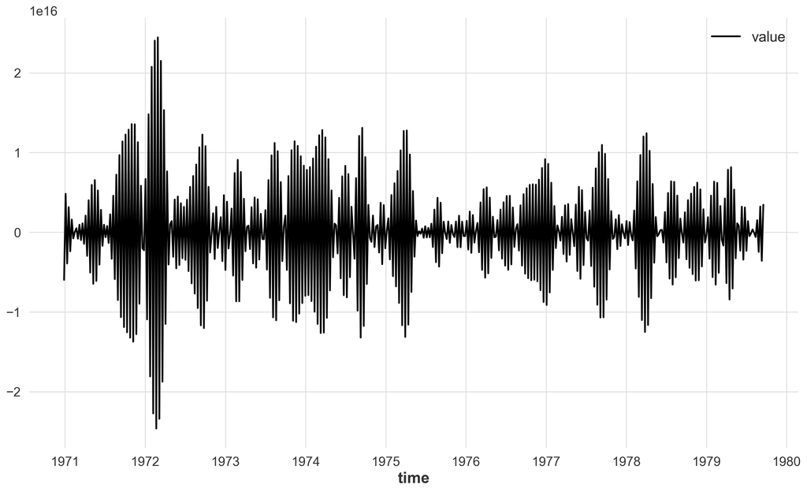

```python
fig, ax = plt.subplots(figsize=(16,9))
cmort_sdiff_ts.plot(ax=ax)
```

```python
freq2, psd2 = periodogram(cmort_sdiff_ts.values().flatten(), fs=52.18)
```

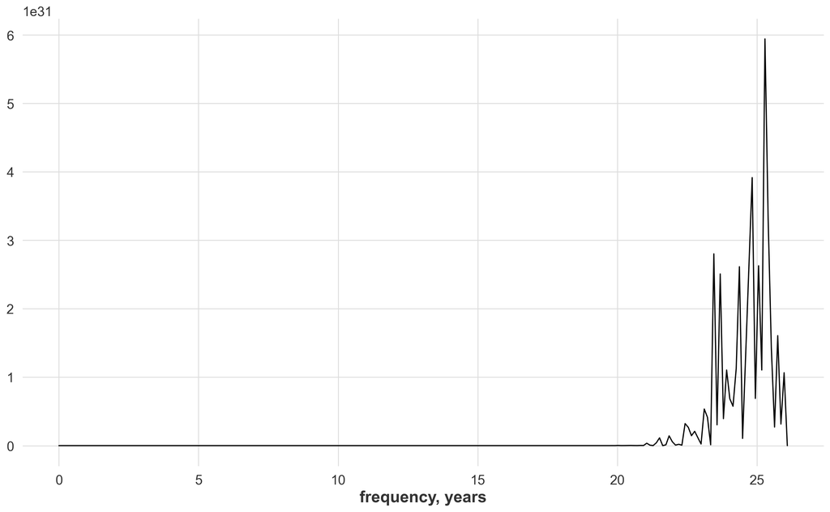

```python
fig, ax = plt.subplots(figsize=(16,9))
ax.plot(freq2, psd2)
ax.set_xlabel("frequency, years")
```

```python
52/21
```

```
2.4761904761904763
```

```python
52/26
```

```
2.0
```

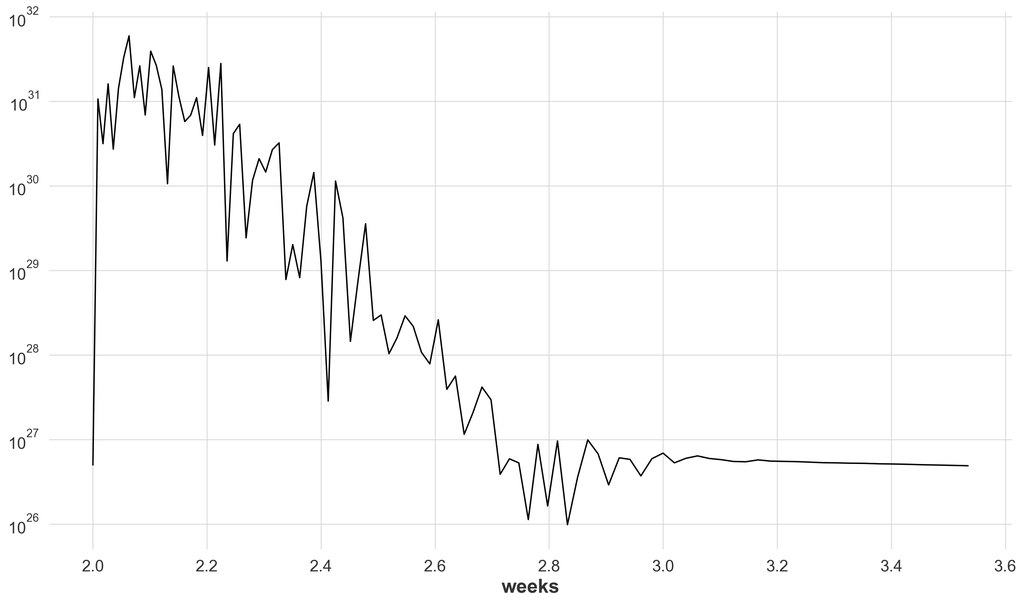

```python
fig, ax = plt.subplots(figsize=(16,9))
ax.semilogy(52.18/freq2[-100:], psd2[-100:])
ax.set_xlabel("weeks")
```

```python
speech_ts = TimeSeries.from_series(speech.reset_index(drop=True))
```

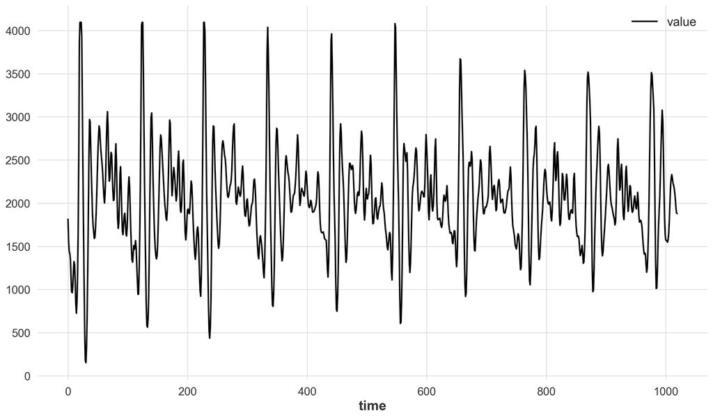

```python
fig, ax = plt.subplots(figsize=(16,9))
speech_ts.plot(ax=ax)
```

```python
freq3, psd3 = periodogram(speech_ts.values().flatten())
```

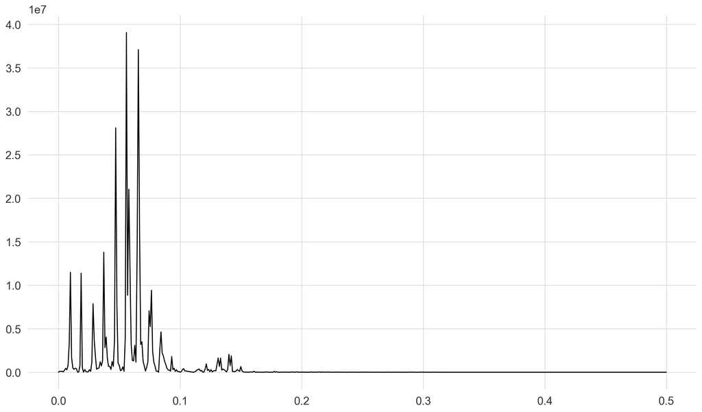

```python
fig, ax = plt.subplots(figsize=(16,9))
ax.plot(freq3, psd3)
```

```python
freq3[find_peaks(psd3, threshold=5e6)[0]]
```

```
array([0.00980392, 0.01862745, 0.0372549 , 0.04705882, 0.05588235,
       0.05784314, 0.06568627])
```

```python
1/freq3[find_peaks(psd3, threshold=5e6)[0]]
```

```
array([102.        ,  53.68421053,  26.84210526,  21.25      ,
        17.89473684,  17.28813559,  15.2238806 ])
```